# GitHub Copilot in VS Code

Optional self-study content for week 9

Author

Affiliations

Jelmer Poelstra

[CFAES Bioinformatics Core, Ohio State University](https://go.osu.edu/bioinformatics-core)

[Dept. of Plant Pathology, Ohio State University](https://plantpath.osu.edu)

Published on

October 9, 2026

Page last modified

October 21, 2026

## 1 Introduction

In class, we used the Claude extension in VS Code Server (see the week 9 lecture). Claude is great for chat and agent-style help, but it does not give you **code completions**: AI suggestions that appear in the editor as you type. Additionally, you can only continue to use Claude after this course if your PI supports an Ohio State Generative AI account, or if you get a personal account[^1].

This page focuses on GitHub Copilot, which in VS Code is a built-in feature. Here is how it compares to Claude Code (as also shown in the week 8 slides):

| Feature | GitHub Copilot | Claude Code |
| --- | --- | --- |
| Code completions | ✅ | ❌ |
| Agentic chat | ✅ | ✅ |
| Free use with a personal, “academic” account | ✅ [^2] | ❌ |
| Can be paid for with university funds | ❌ | ✅ |
| Approved for use with institutional data | ❌ | ✅ |
| *Often considered the best AI coding tool* | ❌ | ✅ |

On this page, you will learn how to:

- Get free extended access to GitHub Copilot as a student
- Sign in to GitHub Copilot and enable its code completions in VS Code
- Use GitHub Copilot’s code completions, inline chat, and chat to help you with coding tasks

As pointed out in the table above: unlike the Claude setup we use in class, GitHub Copilot is **not an OSU-approved tool**. This is true even though the similarly named Microsoft Copilot *is* OSU-approved: these are separate products from the same company[^3]. So, whenever you use GitHub Copilot, you must be aware of the data privacy implications outlined in the week 8 lecture.

## 2 Enabling and authenticating GitHub Copilot

### 2.1 About access to GitHub Copilot

Anyone with a GitHub account is automatically enrolled in the “**Copilot Free**” plan, which provides quite limited access to Copilot’s features, but at least you can try it out. As students and teachers/faculty, we can get additional free access after applying for it. While teachers can get access to the “**Copilot Pro**” plan, which can also be bought by individuals for $10/month, students get access to the more limited “**Copilot Student**” plan.

GitHub is increasingly vague about the limits of its plans, especially the Free and Student plans, but here is an approximate summary (where an “AI Credit” is roughly a single chat request):

[output not shown]

**NoteThe plan overview as per GitHub’s documentation *(click to expand)**

Here is how GitHub itself currently describes the differences between the plans ([source](https://docs.github.com/en/copilot/concepts/billing/individual-plans)):

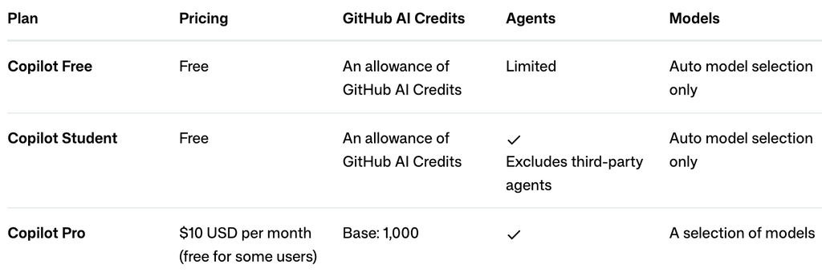

GitHub’s overview of the plans discussed above (there are more plans).

**WarningYou should have applied for the Student plan in class. If not, click here.**

1. Go to https://github.com/settings/education/benefits .
2. Click “**Start an application**”:

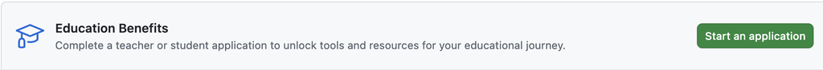

3. Fill out the form as needed. *(You may need a document that proves your current status at the university.)*

Application approval is often quite fast (sometimes in minutes), but **access is only granted 72 hours after approval**. You can already sign in and use the Free plan in the meantime.

### 2.2 Sign in to GitHub Copilot in VS Code

First, start a VS Code Server session at OSC in `/fs/ess/PAS3493/people/$USER`, as usual. Then, use `File` > `Open Folder` to open your `week09` dir from the lecture. Just like Claude, Copilot treats this folder as its workspace.

**WarningYou should have already *enabled* GitHub Copilot in class. If not, click here.**

1. Open the VS Code Settings ( > Settings) and enter “`chat.disableAIFeatures`” in the search bar:

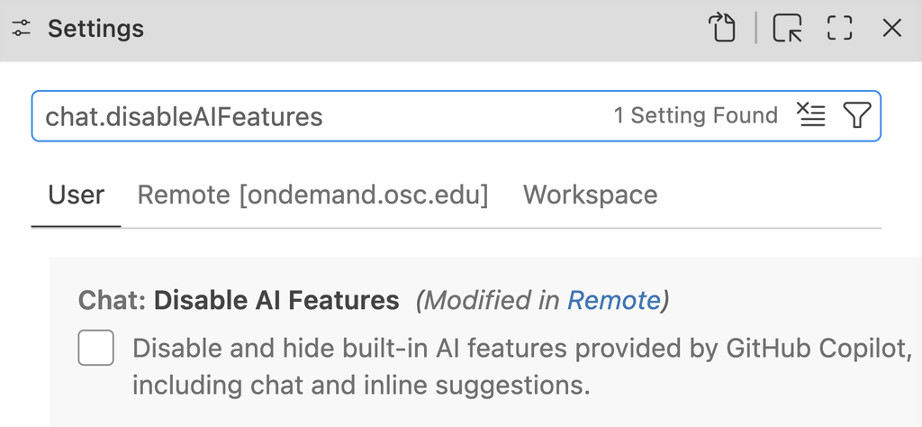

2. Click on the “`Remote [ondemand.osc.edu]`” tab header:

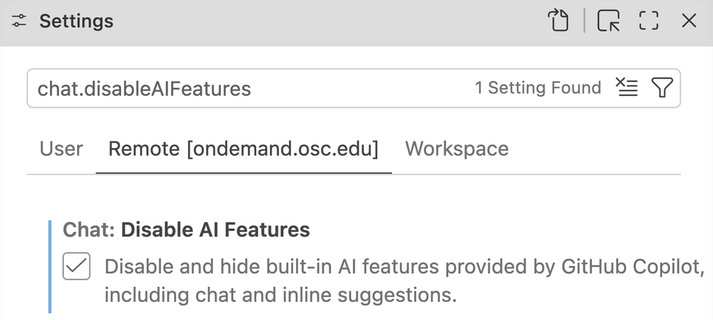

3. Uncheck the box next to “`Chat: Disable AI Features`”:

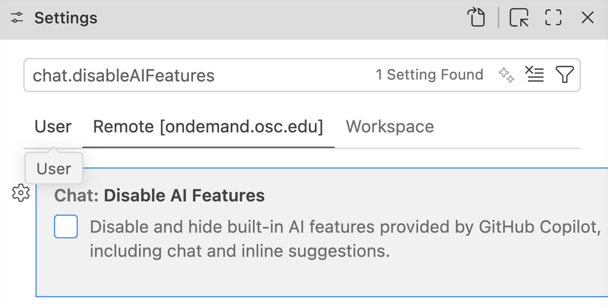

4. Now, the secondary side bar with Claude should also have a “`CHAT`” tab. Click that and the side bar should show something like the screenshot below:

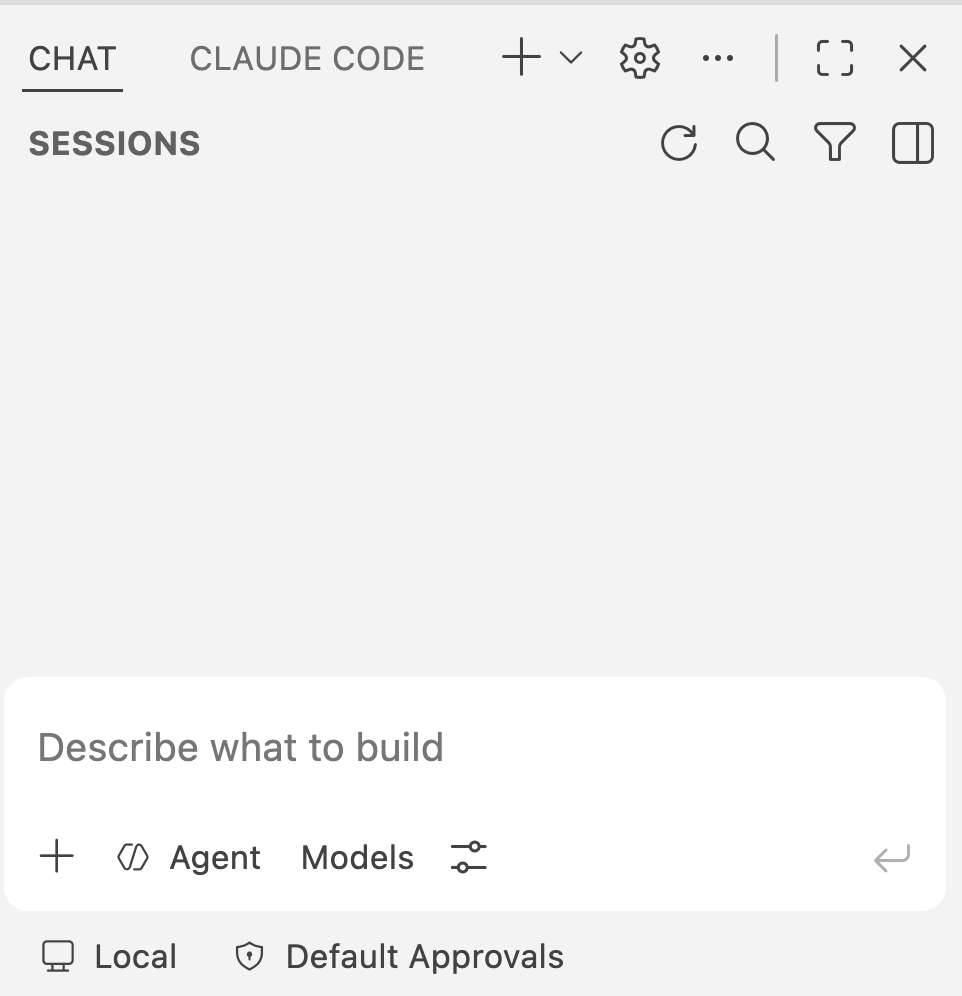

1. Click “**Sign In**” next to the Copilot icon in the status bar at the bottom of the window. (If you’re not seeing the Copilot icon, OSC’s VS Code Server may have reverted to its default setting of disabling AI features: follow the instructions in the previous box to enable them again.)

[figure not shown]

The GitHub Copilot icon in the status bar at the bottom, with a “Sign In” button next to it.

2. Click “**Continue with GitHub**” and continue to follow the prompts to authenticate with your GitHub account.

**Click here for a step-by-step guide to signing in**

- This is where you click “Continue with GitHub”:

[figure not shown]

- VS Code will show you a one-time code. Click “**Copy & Continue to Browser**”, which copies the code:

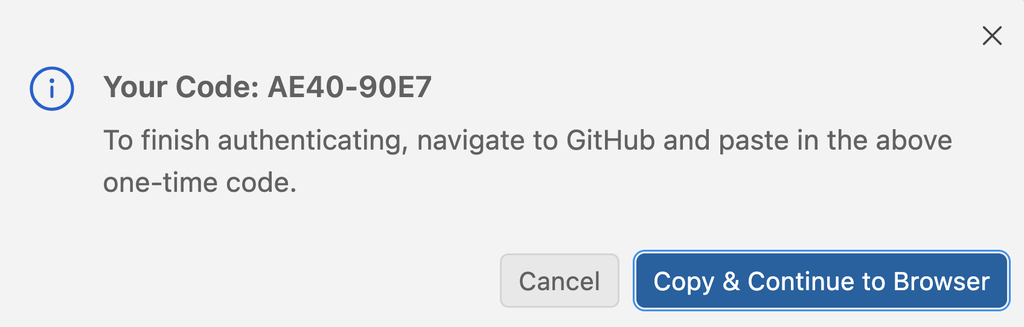

- Click “**Open**” to allow VS Code to open the GitHub website in a new browser tab:

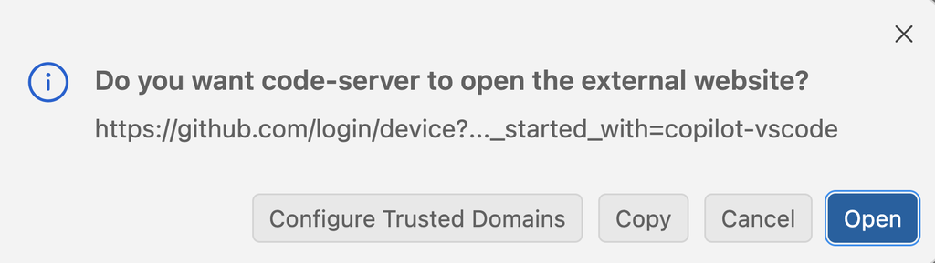

- In the new browser tab, check that you are signed in to the correct GitHub account and click “**Continue**”:

[figure not shown]

- Paste the code that you copied earlier and click “**Continue**”:

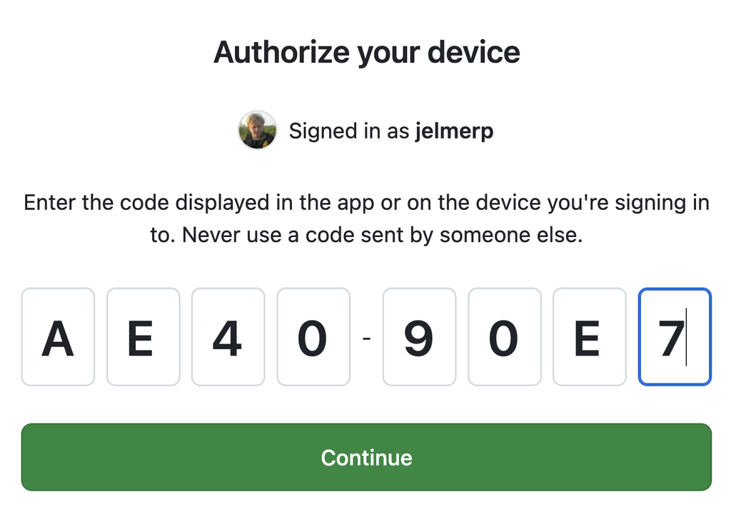

**TipLost the code? *(Click to expand)**

Back in VS Code, a notification in the bottom right also shows the code:

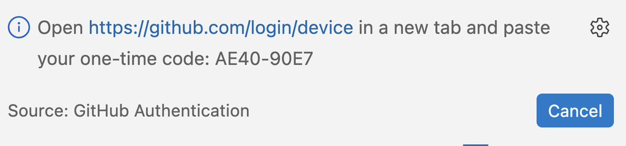

- On the “Authorize Visual Studio Code” page, scroll down and click “**Authorize Visual-Studio-Code**”:

[figure not shown]

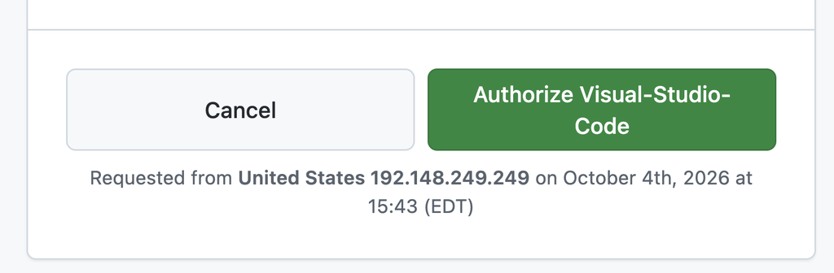

The page shows that this request came from an OSC IP address (starting with `192.148`) — that’s expected, because VS Code Server runs at OSC rather than on your computer.

- GitHub may ask you to confirm access with your passkey, password, or two-factor authentication:

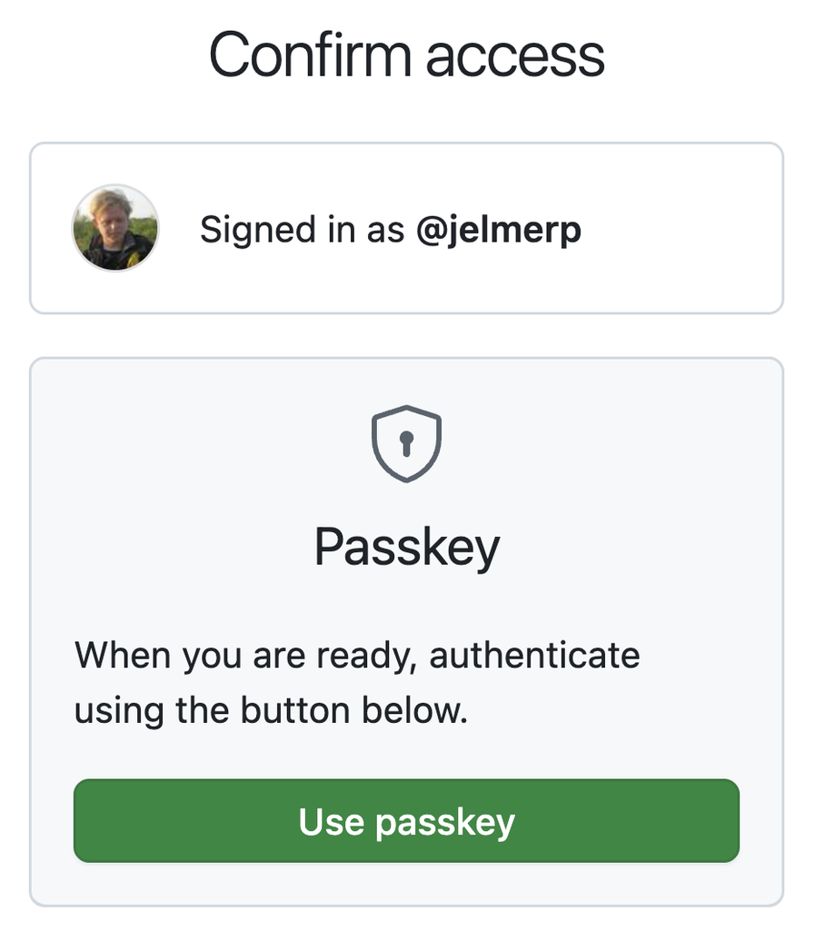

After this, you can close the browser tab and go back to VS Code.

### 2.3 Enabling code completions

Click the Copilot icon in the status bar at the bottom again:

- It shows your plan and how much of your monthly allowance you have used.
- Code completions, which VS Code calls “Inline Suggestions”, *may* be disabled by default, as in the screenshot on the right.

If inline suggestions are disabled, enable them as follows:

1. Open the Command Palette: > Command Palette (or `Ctrl/Cmd`+`Shift`+`P`).
2. Type “copilot inline” and select `GitHub Copilot: Enable Inline Suggestions`:

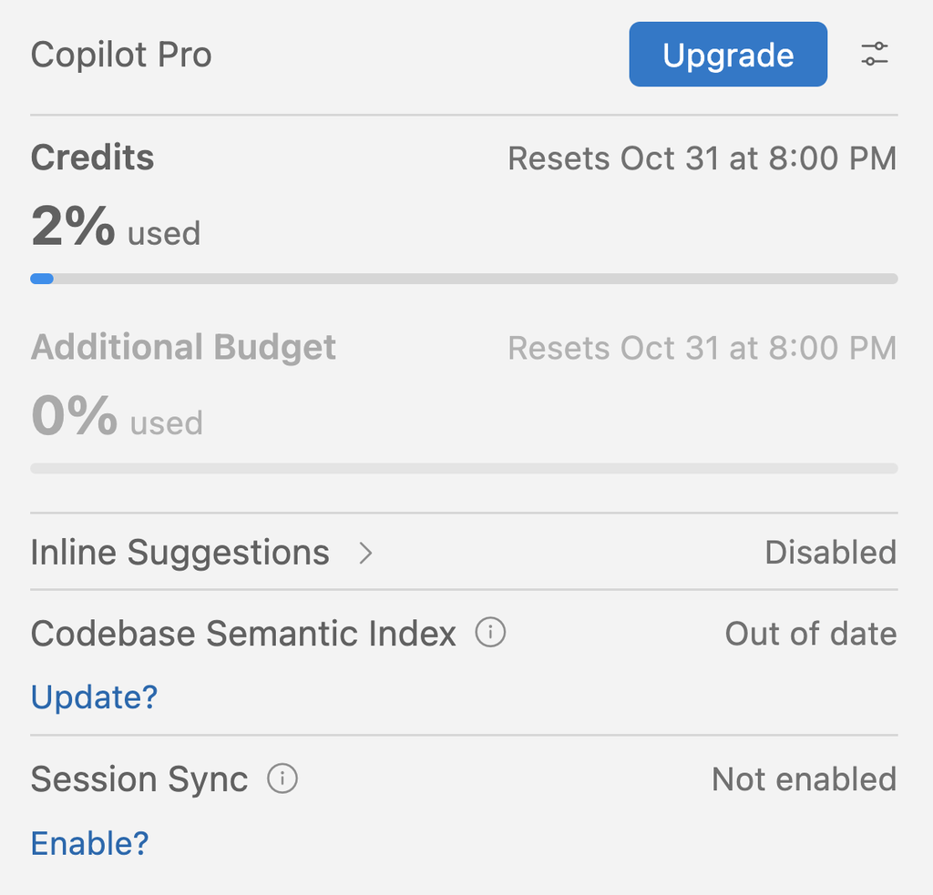

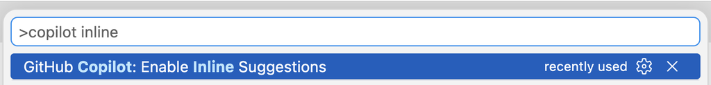

3. Click the Copilot icon once more, and make sure that both boxes under “Inline Suggestions” are checked (these are the two types of code completions discussed below):

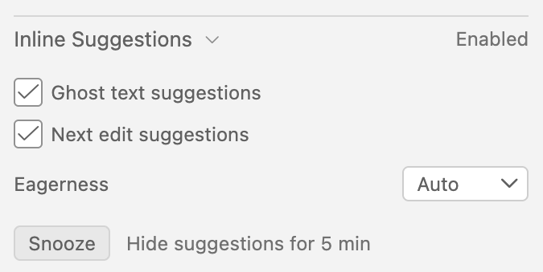

## 3 Intro to code completions

### 3.1 What are code completions?

“[Code completions](https://docs.github.com/en/copilot/how-tos/get-code-suggestions/get-ide-code-suggestions)”, also known as “code suggestions” or, in VS Code, “inline suggestions”, are suggestions for additional or modified code (or other text) that Copilot shows right in the editor as you type. There are two types of code completions:

- **Ghost text suggestions** add new code at your cursor.
- **Next edit suggestions** change code that you have already written.

We’ll go over these one by one. After that, we’ll turn to Copilot’s chat, and in an appendix, to **inline chat**, a related feature that also works right in the editor.

### 3.2 Set up a practice file

You’ll work directly in your `week09` dir while following along with this page. Start by making a decompressed copy of the GTF file in a new `data` dir, for easy access:

```bash
# You should be in /fs/ess/PAS3493/people/$USER/week09
mkdir -p data
zcat ../garrigos/ref/annot.gtf.gz > data/annot.gtf
```

Finally, create a file `copilot.sh`, and open it in the editor. If Copilot is active, you should see some ghost text startup suggestions in the file already:

[figure not shown]

To run the code in your file, you can either copy it to the terminal and press `Enter`, or use a keyboard shortcut to send the code from the editor to the terminal. You should have set up that shortcut in week 7, but if not, see the next box for instructions.

**NoteWhy a `.sh` file instead of a Markdown file? *(Click to expand)**

In other sessions, you’ve been typing code in a Markdown file and sending it to the terminal from there. Here, we’ll use a file with a `.sh` extension instead, because that makes things a bit easier with Copilot:

- In a `.sh` file, Copilot knows that everything is Bash code, so it will suggest code rather than prose, and comment lines work as prompts.
- You don’t need to create code blocks with backticks.

But note that **this file is not a real shell script** like the ones you wrote in week 7: it is a scratch file whose lines you run one by one in the terminal, just like the code in your Markdown files. You won’t run it with `bash` or `sbatch`, which is why it doesn’t need a shebang line or `set` settings.

**NoteSet a keyboard shortcut to send code from the editor to the terminal *(Click to expand)**

This shortcut will send selected code in the editor to the terminal. When no text is selected, the shortcut sends the line your cursor is on (in VS Code, your entire line is implicitly “selected” when your cursor is on it). To run a multi-line command like a `for` loop, first select all of its lines.

1. Click (bottom-left) > `Keyboard Shortcuts`.
2. Type “Run Selected Text” in the search box, and you should see the option “*Terminal: Run Selected Text in Active Terminal*”.
3. Click on that line, then add the shortcut `Ctrl`+`Enter` (don’t worry about any warnings that other keybindings exist for this action; also, the keyboard shortcut is up to you, but I’d recommend this one).

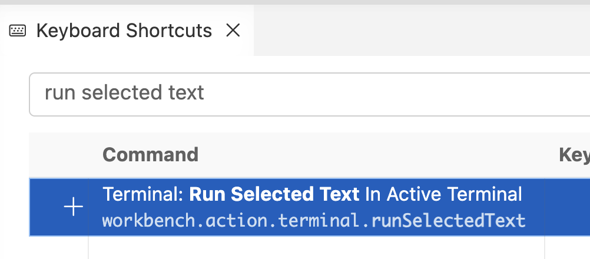

## 4 Ghost text suggestions

Ghost text suggestions are the most common type of code completions. As you type, Copilot shows a suggestion in light gray “ghost text”. Press `Tab` to accept it, or `Esc` to dismiss it (you can also simply keep typing, which dismisses it too). There are two kinds of ghost text suggestions.

### 4.1 Completing what you’re typing

These suggestions try to complete the line you are typing, or suggest a next line based on the previous ones. For example, if you type `#!` in the first line of `copilot.sh`, it’s likely that Copilot will suggest the rest of the shebang line:

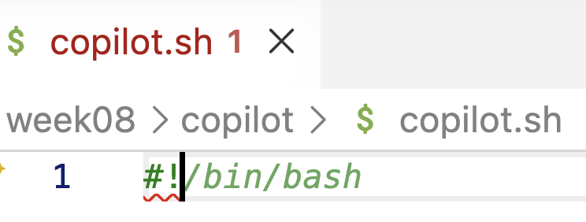

I typed `#!`, and Copilot suggested `/bin/bash` in ghost text.  
It can be a little hard to see the distinction, but the ghost text is fainter than the already typed text.

When you accept the suggestion with `Tab`, the line is completed. And it may immediately suggest a next line:

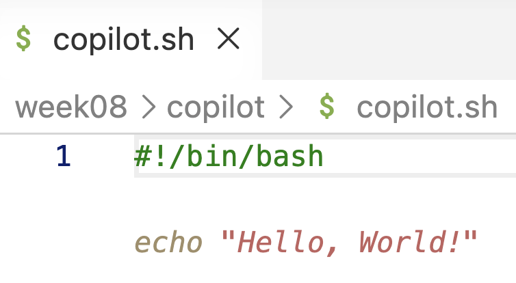

Here, Copilot suggested `echo "Hello, world!"` as a next line.

Press `Esc` to dismiss the suggestion, whatever it is.

**NoteNot just code: an example in a Quarto document *(Click to expand)**

Copilot can help with many kinds of text, not just code. In a Quarto document that is part of the source code of this website, I typed the Markdown syntax to insert an image, `![](/img/claude-interrupt1.png){}`, and Copilot then suggested the part in gray:

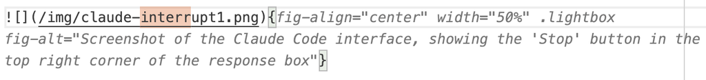

It suggested the formatting options that I typically add to a figure, and even fairly reasonable “alt text” (a description of the image), based on the file name.

We’ll talk about Quarto documents later in the course.

### 4.2 A comment as a prompt

These suggestions generate code that tries to implement what you described in a comment line. This is similar to asking a question in the chat, but can be **faster and more convenient for small tasks**, while less suitable for more complex questions.

Let’s try this in your `copilot.sh` file. First, add the following into it:

```
copilot.sh
```

```bash
# GTF file:
GTF=data/annot.gtf
```

#### A first example

When you go to a new line and wait a second, you may already see a ghost text suggestion that acts on the `GTF` variable. But instead of letting GitHub Copilot go off on its own to randomly suggest ways to interrogate the GTF file, let’s give it a “prompt” by typing a comment line first:

```
copilot.sh (excerpt)
```

```bash
# Count the number of entries in the GTF file
```

You may see a ghost text suggestion appear even with your cursor still at the end of the line, but otherwise, press `Enter` to go to a new line, and wait for a second for the suggestion to appear. Accept it with `Tab` and run the code: does it seem to have given a correct suggestion?

“Entries” means rows in the table part of the GTF file, i.e. excluding the header lines that start with `#`, but this is deliberately a little vague, so Copilot may not always get it right. For example, it may suggest a command that simply counts **all lines** instead. In that case, you could switch the prompt comment to:

```
copilot.sh (excerpt)
```

```bash
# Count the number of entries (non-header lines) in the GTF file
```

A correct answer may well look like this — recall, you can use `grep -v` to exclude lines that start with `#` (“starts with” is expressed as `^` in a regular expression; not covered in class), and then pipe the result into `wc -l` to count the lines:

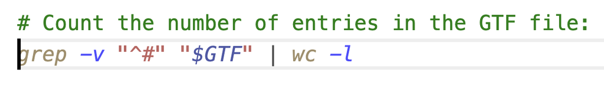

**NoteShellcheck knows better, here *(Click to expand)**

Interestingly, in this specific case, we get a blue squiggly line under the command from shellcheck:

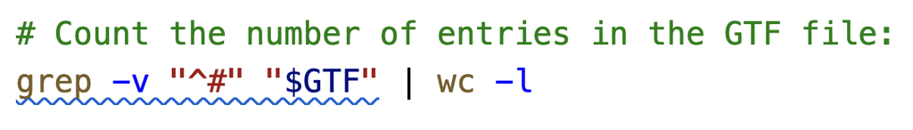

And hovering over the squiggly line shows a shellcheck suggestion for a more efficient and shorter command — we don’t need to pipe into `wc -l`, but can count directly with `grep -c`:

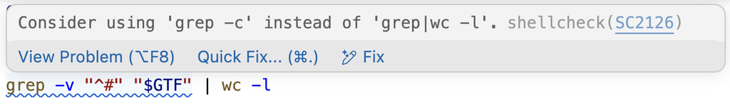

You never know exactly what you’ll get, but when I tried this, Copilot suggested saving the output to a variable, and then `echo`-ing a sentence with the result:

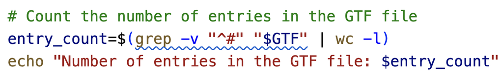

It did this consistently, with the commands below as well. This is neat in a way, but also very verbose. When I deleted the initial command and then added “print directly, no variable” to the prompt comment, it stopped doing this:

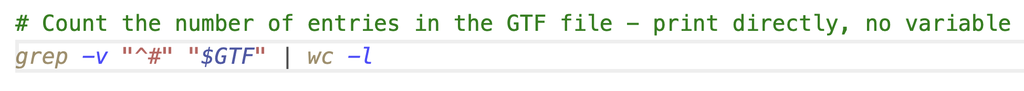